# Data Visualization and Exploratory Data Analysis (EDA) – Basic Level

Dzulfikar Najib

2026-02-17

# **INFORMASI UMUM**

- **Data Visualization**
- **Visual Interpretation**
- **Dataset yang Digunakan**: **Data1**=Test.csv (untuk visualisasi proporsi dan visualisasi hubungan antar peubah numerik), **Data2**=SampleSuperStore.csv (untuk visualisasi hubungan antar peubah numerik), dan **Data3**=Sample - Superstore.csv (untuk visualisasi deret waktu)
- **Sumber Dataset**: Kaggle
- (Data1:https://www.kaggle.com/datasets/kaushiksuresh147/customer-segmentation)
- (Data2:https://www.kaggle.com/datasets/itssuru/super-store)
- (Data3: https://www.kaggle.com/datasets/vivek468/superstore-dataset-final)

# **Visualisasi Proporsi**

## **Persiapan Data (Test)**

```r
library(ggplot2)
library(dplyr)
library(treemap)
library(ggrepel)
library(corrplot)
library(networkD3)
library(viridis)
library(shadowtext)
library(lubridate)
library(scales)
path1 <- "C:/Users/Hype AMD/OneDrive - apps.ipb.ac.id/A UP MY HARD SKILL/IPB/Matakuliaih/Semester 4/Visualisasi Data/Pertemuan 3/Test.csv"
data1 <- read.csv(path1, sep=",") # Pakai path1, bukan path


path2 <- "C:/Users/Hype AMD/OneDrive - apps.ipb.ac.id/A UP MY HARD SKILL/IPB/Matakuliaih/Semester 4/Visualisasi Data/Pertemuan 3/SampleSuperStore.csv"
data2 <- read.csv(path2, sep=",")

path3 <- "C:/Users/Hype AMD/OneDrive - apps.ipb.ac.id/A UP MY HARD SKILL/IPB/Matakuliaih/Semester 4/Visualisasi Data/Pertemuan 3/Sample - Superstore.csv"
data3 <- read.csv(path3, sep=",", check.names = FALSE)
```

## **NASTED DONUT CHART (Profession berdasarkan segmentation)**

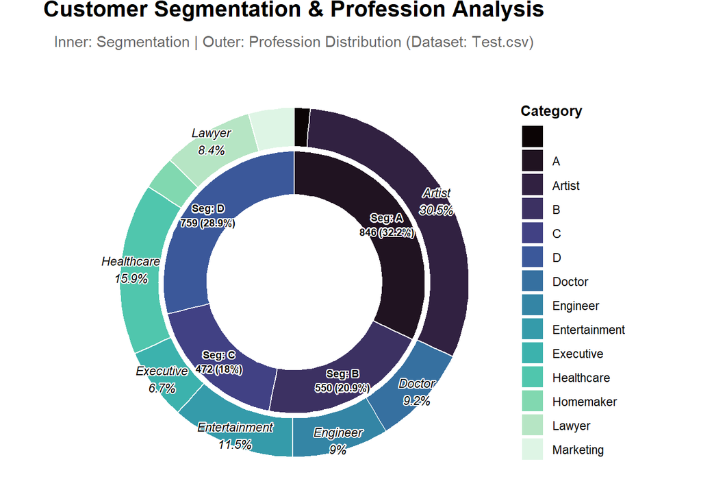

```r
data1 <- as.data.frame(data1)

inner_data <- data1 %>%
  group_by(Segmentation) %>%
  summarise(count = n()) %>%
  mutate(
    fraction = count / sum(count),
    ymax = cumsum(fraction),
    ymin = c(0, head(ymax, n=-1)),
    labelPosition = (ymax + ymin) / 2,
    label = paste0("Seg: ", Segmentation, "\n", count, " (", round(fraction*100, 1), "%)")
  )

outer_data <- data1 %>%
  group_by(Profession) %>%
  summarise(count = n()) %>%
  mutate(
    fraction = count / sum(count),
    ymax = cumsum(fraction),
    ymin = c(0, head(ymax, n=-1)),
    labelPosition = (ymax + ymin) / 2,
    label = paste0(Profession, "\n", round(fraction*100, 1), "%")
  )

p <- ggplot() +

  # Cincin Dalam: Segmentation (Radius 2 ke 3)
  geom_rect(data = inner_data,
            aes(ymax=ymax, ymin=ymin, xmax=3, xmin=2, fill=Segmentation),
            color="white", size=0.5) +

  # Cincin Luar: Profession (Radius 3.1 ke 4)
  geom_rect(data = outer_data,
            aes(ymax=ymax, ymin=ymin, xmax=4, xmin=3.1, fill=Profession),
            color="white", size=0.5) +

# Label Cincin Dalam:
geom_shadowtext(data = inner_data,
                aes(x=2.5, y=labelPosition, label=label),
                color="black",           # Warna huruf utama
                bg.color="white",        # Warna garis tepi (outline)
                bg.r=0.15,               # Ketebalan garis tepi
                size=2.5,
                fontface="bold") +

  # Label Cincin Luar (Hanya persentase yang cukup besar)
  geom_shadowtext(data = outer_data %>% filter(fraction > 0.05),
                aes(x = 3.75,
                    y = labelPosition,
                    label = label),
                color = "black",        # Teks hitam
                bg.color = "white",     # Outline putih
                bg.r = 0.12,            # Ketebalan outline sedikit lebih tipis dari label dalam
                size = 3,
                fontface = "italic") +

  coord_polar(theta="y") +
  xlim(c(0, 4)) +

  scale_fill_viridis_d(option = "mako") +

  theme_void() +
  theme(
    legend.position = "right",
    legend.title = element_text(face="bold", size=10),
    plot.title = element_text(hjust=0.5, face="bold", size=16, margin=margin(b=10)),
    plot.subtitle = element_text(hjust=0.5, size=11, color="gray40", margin=margin(b=10))
  ) +
  labs(
    title = "Customer Segmentation & Profession Analysis",
    subtitle = "Inner: Segmentation | Outer: Profession Distribution (Dataset: Test.csv)",
    fill = "Category"
  )
print(p)
```

- Donut chart ini menunjukkan distribusi Segmentation (cincin dalam) dan distribusi Profession (cincin luar) dalam dataset.
- Setiap segmen pada cincin dalam mewakili proporsi masing-masing Segmentation, sedangkan setiap segmen pada cincin luar mewakili proporsi masing-masing Profession.

*Kesimpulan: Visualisasi ini memberikan gambaran yang jelas tentang bagaimana segmen pelanggan Anda terbagi berdasarkan profesi. Segmen A dengan dominasi Artist menunjukkan peluang besar untuk kampanye pemasaran yang ditargetkan pada industri kreatif, sementara Segmen D dengan distribusi profesi yang lebih beragam menunjukkan potensi untuk pendekatan pemasaran yang lebih luas. Profesi dengan kontribusi kecil bisa menjadi area fokus untuk pengembangan produk atau layanan baru guna menarik segmen pasar yang belum tergarap.*

## **TREAMAP (Profession & Segmentation)**

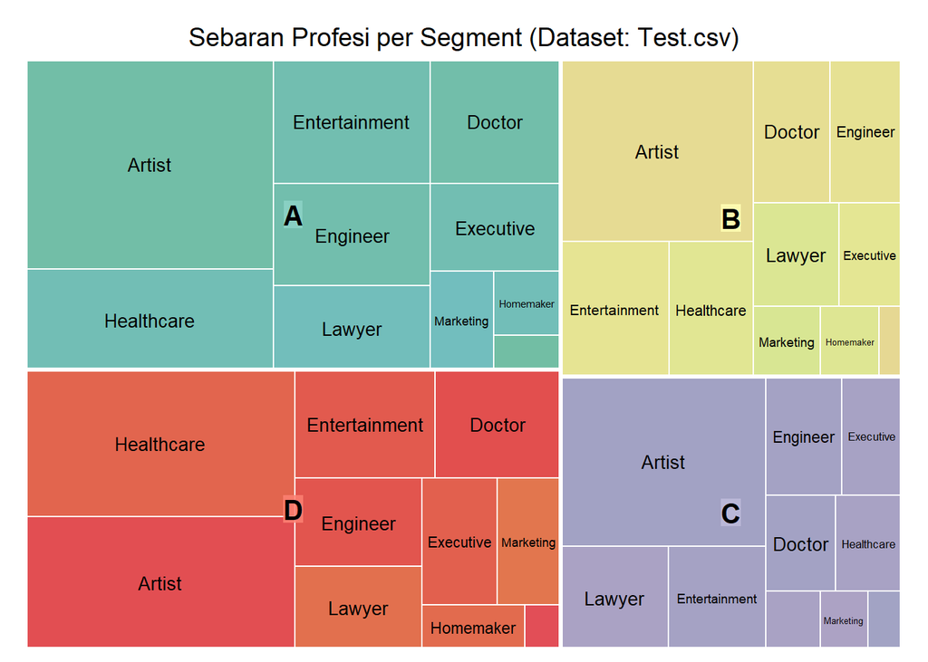

```r
df_tree <- data1 %>%
  filter(!is.na(Segmentation), !is.na(Profession)) %>%
  group_by(Segmentation, Profession) %>%
  summarise(n = n(), .groups = 'drop') %>%
  filter(n > 0) # Untuk memastikan hanya segmen dan profesi dengan jumlah > 0 yang ditampilkan

treemap(df_tree,
        index=c("Segmentation", "Profession"),
        vSize="n",
        type="index",
        title="Sebaran Profesi per Segment (Dataset: Test.csv)",
        palette="Set3",        # Ganti ke "Set3" atau "Pastel1" yang lebih stabil
        border.col="white",
        fontsize.labels=c(15, 10),
        fontcolor.labels="black")
```

## **SANKY DIAGRAM (Gender, Spending_Score, Segmentation)**

```r
df_sankey <- data1 %>%
  select(Gender, Spending_Score, Segmentation) %>%
  na.omit() # Untuk memastikan tidak ada nilai NA yang mengganggu visualisasi

nodes1 <- df_sankey %>%
  group_by(Gender, Spending_Score) %>% # Mengelompokkan data berdasarkan Gender dan Spending_Score
  summarise(value=n(), .groups = 'drop') %>%
  rename(source=Gender, target=Spending_Score)

nodes2 <- df_sankey %>%
  group_by(Spending_Score, Segmentation) %>%
  summarise(value=n(), .groups = 'drop') %>%
  rename(source=Spending_Score, target=Segmentation)

links <- rbind(as.data.frame(nodes1), as.data.frame(nodes2))

nodes_name <- data.frame(name=unique(c(links$source, links$target)))
links$IDsource <- match(links$source, nodes_name$name) - 1
links$IDtarget <- match(links$target, nodes_name$name) - 1

sankeyNetwork(Links = links, Nodes = nodes_name,
              Source = "IDsource", Target = "IDtarget",
              Value = "value", NodeID = "name",
              fontSize = 14, nodeWidth = 40)
```

[interactive chart not shown]

- Sisi Kiri (Gender): Menunjukkan Gender di mana Female adalah blok biru tua (atas) dan Male adalah blok biru muda (bawah).
- Sisi Tengah (Spending Score): Menunjukkan tingkat pengeluaran yaitu Low (hijau), Average (oranye tua), dan High (oranye muda).
- Sisi Kanan (Segmentation): Menunjukkan segmentasi konsumen yaitu A (hijau muda), B (merah), C (pink/salem), dan D (ungu).
- Lebar Aliran: Menunjukkan jumlah populasi/sampel (semakin tebal alirannya, semakin banyak jumlahnya).
- Warna Aliran: Aliran berwarna abu-abu transparan yang menghubungkan antar kategori untuk memudahkan pelacakan distribusi data.

#### **Dari diagram Sankey yang menghubungkan Gender, Spending_Score, dan Segmentation, kita dapat menginterpretasikan beberapa pola dan hubungan sebagai berikut:**

##### Aliran Gender ke Spending Score:

- Kelompok ‘Female’ memiliki proporsi aliran yang besar menuju ‘Low’ spending score, namun juga berkontribusi signifikan pada kategori ‘Average’.
- Kelompok ‘Male’ terlihat memiliki distribusi yang cukup merata, namun aliran menuju ‘Average’ dan ‘Low’ tetap yang paling dominan.
- Kategori ‘High’ spending score menerima aliran yang paling tipis dari kedua gender dibandingkan kategori lainnya.

##### Aliran Spending Score ke Segmentation:

- Kelompok ‘Low’ Spending Score: Mengalir paling besar ke Segmen D (ungu) dan Segmen A (hijau). Ini menunjukkan Segmen D dan A didominasi oleh orang-orang dengan pengeluaran rendah.
- Kelompok ‘Average’ Spending Score: Mayoritas mengalir ke Segmen B (merah) dan Segmen C (pink). Artinya, Segmen B dan C adalah target konsumen dengan pengeluaran menengah.
- Kelompok ‘High’ Spending Score: Alirannya tersebar cukup kecil ke semua segmen, namun terlihat cukup konsisten masuk ke Segmen C dan B.

*Kesimpulan: Terdapat pola yang jelas di mana tingkat pengeluaran (Spending Score) menjadi penentu utama dalam pembagian segmen. Segmen A dan D adalah kelompok pengeluaran rendah, sedangkan Segmen B dan C adalah kelompok pengeluaran menengah hingga tinggi.*

# **Visualisasi Hubungan Antar Peubah Numerik**

## **Heatmap Korelasi**

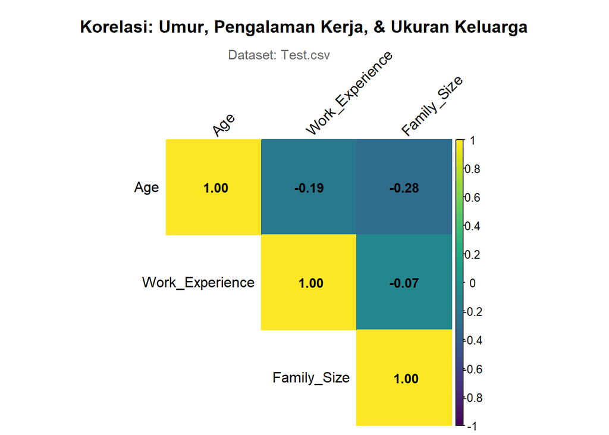

```r
df_numeric <- data1 %>%
  select(Age, Work_Experience, Family_Size) %>%
  na.omit()

res <- cor(df_numeric)

# Membuat visualisasi
corrplot(res,
         method="color",
         type="upper",
         addCoef.col = "black",
         tl.srt=45,
         tl.col="black",
         title="Korelasi: Umur, Pengalaman Kerja, & Ukuran Keluarga",
         number.cex=0.9,
         mar=c(0,0,3,0), # Margin atas (3) perlu ada untuk tempat judul
         col=viridis(100))

# Menambahkan Subtitle
mtext("Dataset: Test.csv", side=3, line=0.5, cex=0.9, adj=0.45, col="gray40")
```

- Heatmap korelasi menunjukkan hubungan antara variabel numerik Age, Work_Experience, dan Family_Size. - Warna menunjukkan kekuatan dan arah korelasi, dengan angka di dalam kotak menunjukkan nilai korelasi secara spesifik.

#### **Berdasarkan hasil heatmap korelasi di atas, kita bisa menginterpretasikan hubungan antara variabel-variabel numerik sebagai berikut:**

- Age & Work_Experience (-0.19): Terdapat korelasi negatif yang lemah. Dari korelasi menunjukkan bahwa dalam dataset ini, bertambahnya usia tidak menjamin pengalaman kerja yang lebih tinggi; ada tren kecil yang justru menunjukkan sebaliknya.
- Age & Family_Size (-0.28): Terdapat korelasi negatif lemah. Responden yang berusia lebih tua cenderung memiliki ukuran keluarga yang lebih kecil dalam sampel data ini.
- Work_Experience & Family_Size (-0.07): Angka ini mendekati nol, yang berarti hampir tidak ada hubungan linier antara pengalaman kerja seseorang dengan jumlah anggota keluarganya.

*Kesimpulan: Secara keseluruhan, ketiga variabel ini tidak menunjukkan korelasi yang kuat satu sama lain, yang mengindikasikan bahwa faktor-faktor seperti usia, pengalaman kerja, dan ukuran keluarga mungkin dipengaruhi oleh variabel lain yang tidak termasuk dalam analisis ini atau memiliki hubungan yang lebih kompleks daripada sekadar linier.*

## **Scatter Plot: Sales vs Profit (basic)**

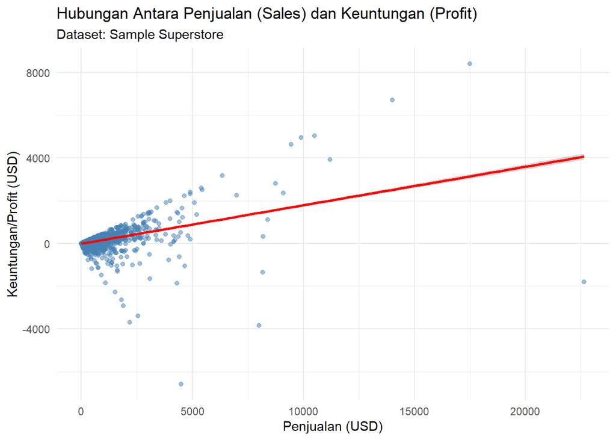

```r
ggplot(data2, aes(x = Sales, y = Profit)) +
  geom_point(alpha = 0.5, color = "steelblue") +
  # Menambahkan garis regresi linear untuk menunjukkan tren umum antara Sales dan Profit
  geom_smooth(method = "lm", formula = y ~ x, se = TRUE, color = "red") +
  labs(title = "Hubungan Antara Penjualan (Sales) dan Keuntungan (Profit)",
       subtitle = "Dataset: Sample Superstore",
       x = "Penjualan (USD)",
       y = "Keuntungan/Profit (USD)") +
  theme_minimal()
```

## **Scatter Plot: Sales vs Profit (dengan outliers)**

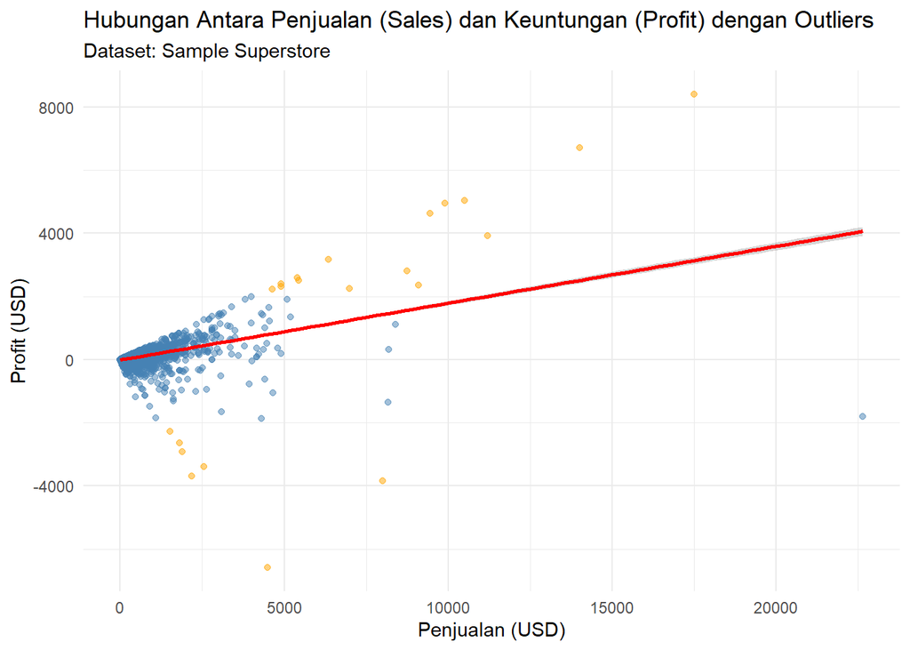

```r
data2$label_outlier <- ifelse(data2$Sales > 5000 | abs(data2$Profit) > 2000,
                             as.character(data2$Product_Name), NA)

ggplot(data2, aes(x = Sales, y = Profit)) +
  geom_point(aes(color = abs(Profit) > 2000), alpha = 0.5) +
  geom_smooth(method = "lm", formula = y ~ x, se = TRUE, color = "red") +

  # na.rm = TRUE buat ngilangin pesan error/warning
  geom_text_repel(aes(label = label_outlier),
                  size = 3,
                  na.rm = TRUE,
                  box.padding = 0.5) +

  scale_color_manual(values = c("steelblue", "orange")) +
  labs(title = "Hubungan Antara Penjualan (Sales) dan Keuntungan (Profit) dengan Outliers",
       subtitle = "Dataset: Sample Superstore",
       x = "Penjualan (USD)", y = "Profit (USD)") +
  theme_minimal() +
  theme(legend.position = "none")
```

- Scatter plot menunjukkan hubungan antara Sales (sumbu X) dan Profit (sumbu Y).
- Titik-titik biru menunjukkan data individual, sementara garis merah menunjukkan tren umum (regresi linear) antara kedua variabel.

#### **Dari visualisasi scatter plot antara Sales dan Profit, kita dapat menginterpretasikan beberapa pola dan insight sebagai berikut:**

- Tren Hubungan Positif: Scatter plot menunjukkan adanya korelasi positif antara Penjualan (Sales) dan Keuntungan (Profit). Garis regresi berwarna merah mengonfirmasi bahwa secara umum, peningkatan nilai penjualan diikuti oleh peningkatan laba bersih.
- Stabilitas Data: Hubungan ini terlihat paling stabil pada transaksi skala kecil hingga menengah (Sales < 5.000 USD), di mana titik data cenderung mengumpul dekat dengan garis tren.
- Variabilitas Data: Seiring bertambahnya nilai Sales, sebaran data makin melebar. Ini menunjukkan bahwa pada transaksi besar, Sales tidak lagi menjadi satu-satunya penentu keuntungan. Faktor lain (seperti diskon atau biaya logistik) mulai mendominasi.
- Identifikasi Outliers (Pencilan): **High Profit Sales:** Ditemukan transaksi dengan Sales menengah namun menghasilkan profit yang sangat tinggi (jauh di atas garis regresi). Ini adalah area transaksi paling efisien. **Critical Negative Outliers (Boncos):** Terdeteksi transaksi dengan volume Sales sangat besar (> 20.000 USD) namun mencatatkan profit negatif.Ini adalah outlier berbahaya yang menunjukkan adanya inefisiensi fatal, kemungkinan akibat kebijakan diskon yang terlalu agresif atau pembengkakan biaya operasional/pengiriman pada proyek besar.

*Kesimpulan Strategis: Secara keseluruhan, strategi meningkatkan volume penjualan efektif untuk menaikkan profit. Namun, manajemen perlu melakukan audit terhadap transaksi bernilai besar yang justru merugi guna menjaga stabilitas margin keuntungan perusahaan.*

## **Box Plot: Quantity vs Profit**

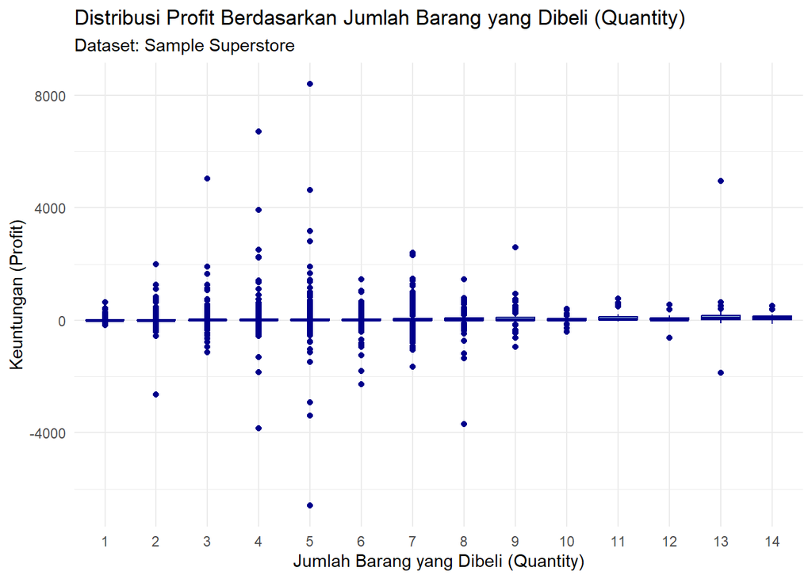

```r
ggplot(data2, aes(x = as.factor(Quantity), y = Profit)) +
  geom_boxplot(fill = "lightblue", color = "darkblue") +
  labs(title = "Distribusi Profit Berdasarkan Jumlah Barang yang Dibeli (Quantity)",
       subtitle = "Dataset: Sample Superstore",
       x = "Jumlah Barang yang Dibeli (Quantity)",
       y = "Keuntungan (Profit)") +
  theme_minimal()
```

- Box plot menunjukkan distribusi Profit untuk setiap kategori Quantity (jumlah barang yang dibeli).
- Setiap box plot mewakili distribusi profit untuk transaksi dengan jumlah barang tertentu, dengan garis tengah (median), kotak (interquartile range), dan whiskers (rentang data yang tidak dianggap outliers).

*Perusahaan perlu memberikan perhatian khusus pada transaksi di “Zona Menengah” (Quantity 4-9). Ketidakpastian profit di zona ini menunjukkan bahwa kebijakan diskon volume mungkin belum optimal, sehingga menyebabkan beberapa transaksi mengalami kerugian besar meskipun volume penjualan mencukupi.*

# **Visualisasi Deret Waktu (Time Series)**

## **Line Plot: Tren Penjualan Bulanan (Total Sales per Month)**

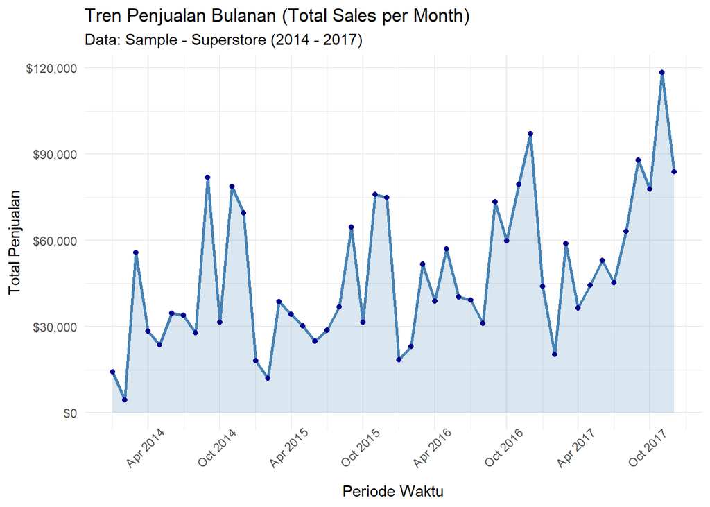

```r
data_monthly <- data3 %>%
  mutate(Order_Date = mdy(`Order Date`)) %>%
  mutate(Month_Year = floor_date(Order_Date, "month")) %>%
  group_by(Month_Year) %>%
  summarise(Total_Sales = sum(Sales, na.rm = TRUE)) %>%
  filter(!is.na(Month_Year))

ggplot(data_monthly, aes(x = Month_Year, y = Total_Sales)) +
  geom_area(fill = "steelblue", alpha = 0.2) +
  # Garis utama
  geom_line(color = "steelblue", size = 1) +
  # Titik setiap bulan
  geom_point(color = "darkblue", size = 1.5) +
  # Format Sumbu Y menjadi Dollar
  scale_y_continuous(labels = label_dollar()) +
  # Atur tampilan Sumbu X agar per tahun
  scale_x_date(date_breaks = "6 months", date_labels = "%b %Y") +
  labs(
    title = "Tren Penjualan Bulanan (Total Sales per Month)",
    subtitle = "Data: Sample - Superstore (2014 - 2017)",
    x = "Periode Waktu",
    y = "Total Penjualan"
  ) +
  theme_minimal() +
  theme(axis.text.x = element_text(angle = 45, hjust = 0.7)) # Miringkan teks tanggal
```

- Line plot ini menunjukkan tren penjualan bulanan (Total Sales per Month) dari tahun 2014 hingga 2017.
- Area di bawah garis memberikan efek visual yang lebih menarik, sementara titik-titik pada setiap bulan membantu mengidentifikasi fluktuasi penjualan secara lebih jelas.

*Kesimpulan: Toko ini punya pola penjualan yang sangat musiman, dengan puncak di akhir tahun dan penurunan di awal tahun. Strategi pemasaran yang fokus pada promo akhir tahun bisa sangat efektif, sementara untuk mengatasi penurunan di awal tahun, mungkin bisa dipertimbangkan untuk mengadakan promo khusus atau memperkenalkan produk baru untuk menarik pelanggan.*